# Peer Assignment 1

## 1. Introduction

It is now possible to collect a large amount of data about personal movement using activity monitoring devices such as Fitbut, Nike Fuelband, or Jawbone Up. These type of devices are part of the “quantified self” movement - a group of enthusiasts who take measurements about themselves regularly to improve their health, to find patterns in their behavior, or because they are tech geeks. But these data remain under-utilized both because the raw data are hard to obtain and there is a lack of statistical methods and software for processing and interpreting the data.

## 2. Codebook

This assignment makes use of data from a personal activity monitoring device. This device collects data at 5 minute intervals dthrough out the day. The data consists of two months of data from an anonymous individual collected during the months of October and November, 2012 and include the number of steps taken in 5 minute intervals each day.

The variables included in this dataset are:

- **steps**: Number of steps taken in a 5-minute interval (missing values are coded as `NA`)
- **date**: The date on which the measurement was taken in YYYY-MM-DD format
- **interval**: Identifier for the 5-minute interval in which measurement was taken
- **time**: Starting time for the measurement of the step count

The dataset is stored in a comma-seperated-value (CSV) file and there are a total of 17,568 observations in the original dataset.

## 3. Loading and preprocessing the data

1. Loading the data

```r
data <- read.csv("./activity.csv")
data$steps <- as.numeric(data$steps)
```

2. Process/ transform data

The code below transforms the interval column into a human and computer readable time in format `HH:MM`, and adds the column to the dataset called `time`.

```r
time <- data$interval
time2 <- mapply(function(x,y) paste0(rep(x,y), collapse=""), 0, 4-nchar(time))
time <- paste0(time2, time)
data$time <- format(strptime(time, format="%H%M"), format="%H:%M")
```

## 4. What is the mean total of steps taken per day?

*Note*: missing values are ignored in this step

1. Calculation of the total number of steps taken per day

```r
sumDay <- aggregate(data$steps, list(data$date), FUN=sum, na.rm=TRUE)
sumDay_table <- data.frame(as.integer(sumDay[,2]), sumDay[,1])
```

2. Histogram of the total number of steps taken each day

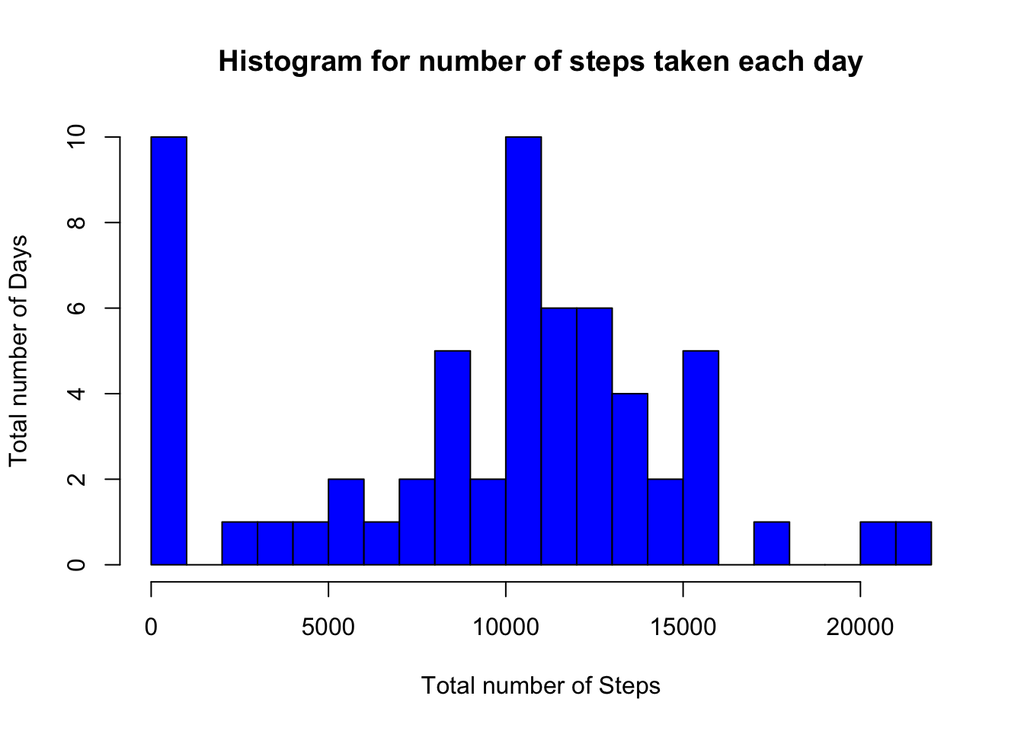

```r
hist(sumDay_table[,1], main="Histogram for number of steps taken each day", xlab="Total number of Steps", ylab="Total number of Days",col="blue", breaks=30)
```

3. Calculation and report mean and median of the total number of steps per day

```r
mean <- mean(sumDay$x)
median <- median(sumDay$x)
```

## 5. The average daily activity pattern

1. Time series plot of the 5-minute interval (x-axis) and the average number of steps taken, averaged across all days (y-axis).

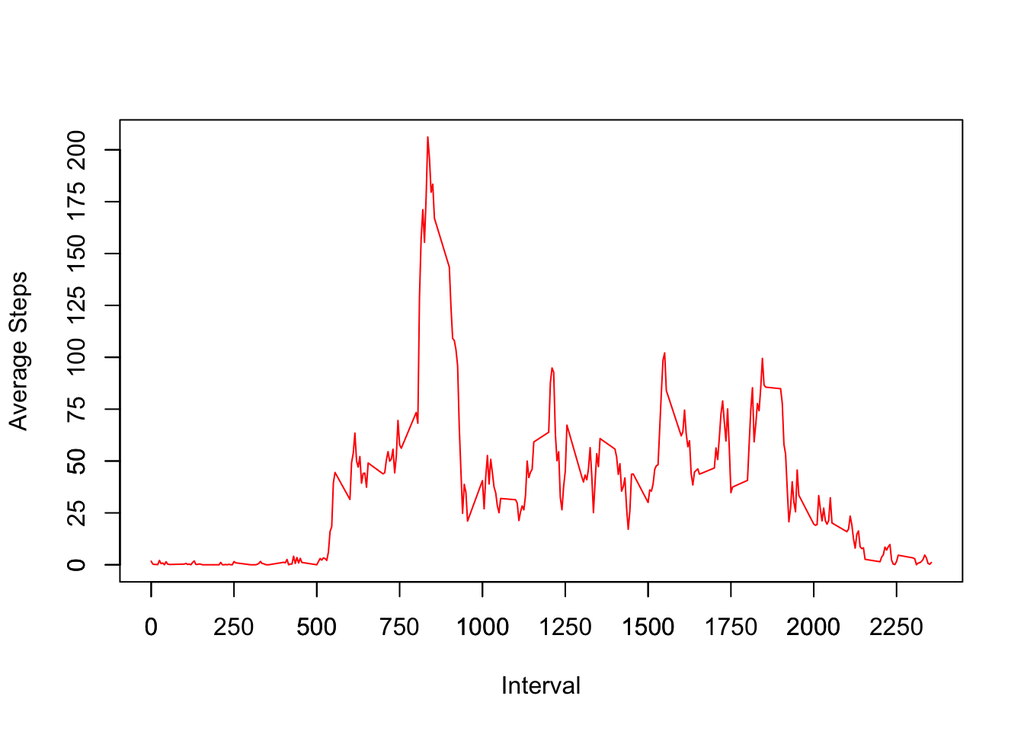

```r
sumInterval <- aggregate(data$steps, list(data$interval), FUN=mean, na.rm=TRUE)
names(sumInterval) <- c("interval", "mean_steps")
plot(sumInterval$interval, sumInterval$mean_steps, type="l", col="red", xlab="Interval", ylab="Average Steps")
axis(side=1, at=seq(0, 2400, by=250))
axis(side=2, at=seq(0, 210, by=25))
```

2. The 5-minute interval, on average across all days in the dataset, with the maximum number of steps.

```r
index <- which(sumInterval$mean_steps == max(sumInterval$mean_steps))
interval <- sumInterval[index,][1]
```

The 5-minute interval, with the highest average number of steps across all days is: **835**.

## 6. Inputing missing values

```r
no_NA <- table(is.na(data$steps))[1]
yes_NA <- table(is.na(data$steps))[2]
```

Thus, in this dataset there are **15264** fields with an actual value. In other words, these are not missing. In total there are **2304** missing values in the dataset.

2. Devise a strategy for filling in all the missing value in the dataset.

A possible strategy to inpute the missing values is to take the average on the interval level and replace any missing value with this average. The following code would do this:

```r
missing <- is.na(data$steps)
data_missing <- data[missing,]

data_missing2 <- data_missing
for(i in 1:length(data_missing[,1])){
  data_missing[i,1] <-sumInterval[which(sumInterval$interval==data_missing[i,3]),2]
}

data_missing
```

[output not shown]

[output cut: 2290 more lines]